# Newark flight delays

this is a study in collaboration with newark airport located in NYC there are 3 airports in this region. this will be both a comparative analysis on the performance of this airport versus its counterparts and also an analysis on natural phenomena that could be affecting the performance of the airport.

specifically, the performance metric studdied in this analysis is the delay of flights, both in frequnancy and in magnitude.

all airports had a similarly comparable rate of delays and asccociated magnitude of delays. however Newark airport appears to have slightly more delays as a percentage of total flights while also haveing a greater number of total flights when compared to the other two local NCY airports.

increased traffic may explain the increase in delay proportion.

weather data for this study was in incredibly short supply, the data for most relevant weather factors was missing to such an extent as to be useless and unreliable for this investigation.

visibility was the only viable statistic for use.

a correlation was discovered between the visibility and the magnitude of delays experienced within that visibility range. far visibility appears to reduce the probability that a flight will be delayed by a large margin.

```r
library(MASS)
library(tidyverse)
library(here)
library(ggplot2)
library(lubridate)
library(GGally)
library(caret)
library(Amelia)
```

create clean data

```r
source(here("scripts/primary_data_cleaning.R"))
```

load clean data

```r
clean_data <- read_csv(here("clean_data/primary_clean_data.csv"), show_col_types = FALSE)
```

basic delay data

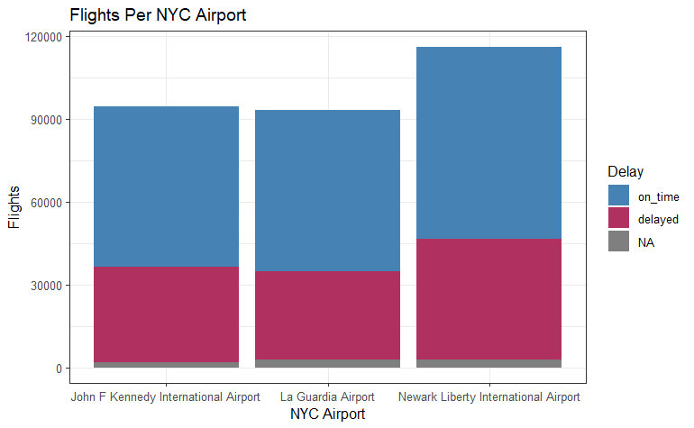

```r
clean_data %>%
group_by(origin_airport_name) %>%
  ggplot() +
  aes(x = origin_airport_name, fill = dep_delay_bool) +
  geom_bar() +
  labs(x = "NYC Airport",
y = "Flights",
title = "Flights Per NYC Airport",
fill = "Delay") +
  scale_fill_manual(labels = c("on_time", "delayed"), values = c("steelblue", "maroon")) +
  theme_bw()
```

```r
NA
NA
```

significant delays all round, more delays in newark but more flights total. there seems to be no imbalance

```r
clean_data %>%
  select(origin_airport_name, dep_delay_bool) %>%
  na.omit() %>%
group_by(origin_airport_name) %>%
  summarise(percentage_delay = sum(dep_delay_bool)/n()*100)
```

| origin_airport_name | percentage_delay |
| --- | --- |
| John F Kennedy International Airport | 37.33091 |
| La Guardia Airport | 35.40104 |
| Newark Liberty International Airport | 38.60454 |

there is an increase in delay percentage upon numerical analysis, however the gravity of this statistic is yet to be determined

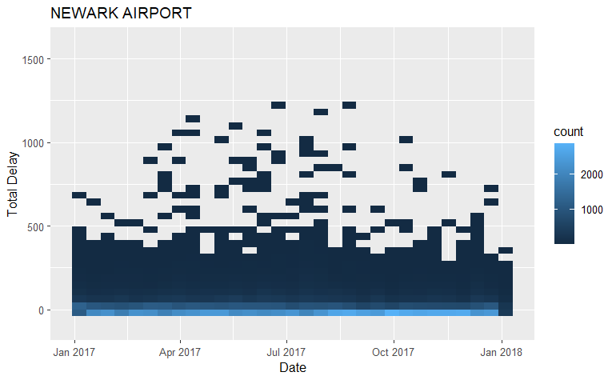

```r
clean_data %>%
  filter(origin_airport_name == "Newark Liberty International Airport") %>%
  ggplot() +
  aes(x = POSIXct_local_time, y = dep_delay) +
  geom_bin2d() +
  coord_cartesian(ylim = c(-100, 1600)) +
  labs(title = "NEWARK AIRPORT", x = "Date", y = "Total Delay")
```

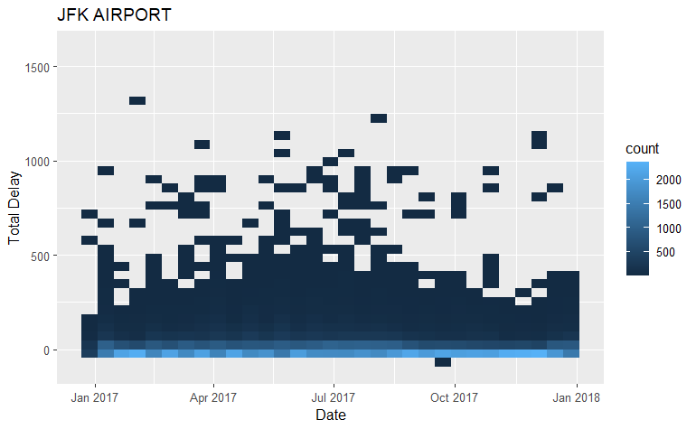

```r
clean_data %>%
  filter(origin_airport_name == "John F Kennedy International Airport") %>%
  ggplot() +
  aes(x = POSIXct_local_time, y = dep_delay) +
  geom_bin2d()+
  coord_cartesian(ylim = c(-100, 1600)) +
  labs(title = "JFK AIRPORT", x = "Date", y = "Total Delay")
```

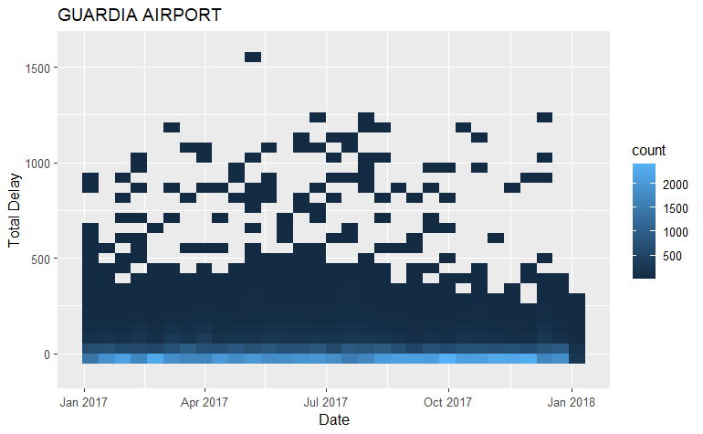

```r
clean_data %>%
  filter(origin_airport_name == "La Guardia Airport") %>%
  ggplot() +
  aes(x = POSIXct_local_time, y = dep_delay) +
  geom_bin2d()+
  coord_cartesian(ylim = c(-100, 1600)) +
  labs(title = "GUARDIA AIRPORT", x = "Date", y = "Total Delay")
```

possible delay cluster spike in the summer, vast majority of delays are concentrated in the minor catagory across all airports

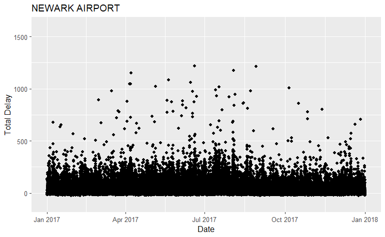

```r
clean_data %>%
  filter(origin_airport_name == "Newark Liberty International Airport") %>%
  ggplot() +
  aes(x = POSIXct_local_time, y = dep_delay) +
  geom_point() +
  coord_cartesian(ylim = c(-100, 1600)) +
  labs(title = "NEWARK AIRPORT", x = "Date", y = "Total Delay")
```

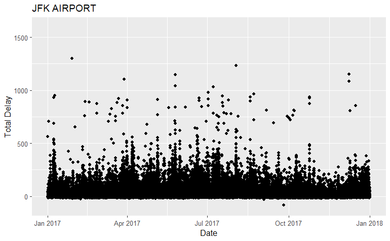

```r
clean_data %>%
  filter(origin_airport_name == "John F Kennedy International Airport") %>%
  ggplot() +
  aes(x = POSIXct_local_time, y = dep_delay) +
  geom_point()+
  coord_cartesian(ylim = c(-100, 1600)) +
  labs(title = "JFK AIRPORT", x = "Date", y = "Total Delay")
```

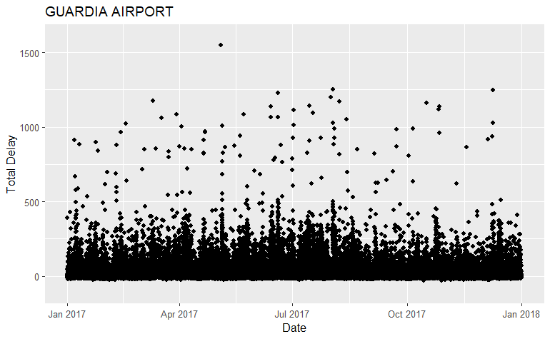

```r
clean_data %>%
  filter(origin_airport_name == "La Guardia Airport") %>%
  ggplot() +
  aes(x = POSIXct_local_time, y = dep_delay) +
  geom_point()+
  coord_cartesian(ylim = c(-100, 1600)) +
  labs(title = "GUARDIA AIRPORT", x = "Date", y = "Total Delay")
```

identical plot with less granularity, no significant new information

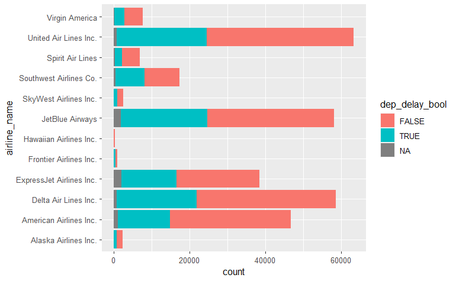

```r
clean_data %>%
group_by(airline_name) %>%
  ggplot() +
  aes(y = airline_name, fill = dep_delay_bool) +
  geom_bar()
```

no apparent significant delays by airline

delay analysis over time

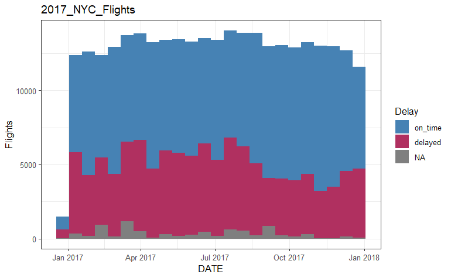

```r
clean_data %>%
  ggplot() +
  geom_histogram(aes(x = POSIXct_local_time, fill = dep_delay_bool), bins = 24) +
  labs(x = "DATE",
y = "Flights",
title = "2017_NYC_Flights",
fill = "Delay") +
  scale_fill_manual(labels = c("on_time", "delayed"), values = c("steelblue", "maroon")) +
  theme_bw()
```

delays seem slightly more frequent from march to august supporting previous hipothosis

by day analysis

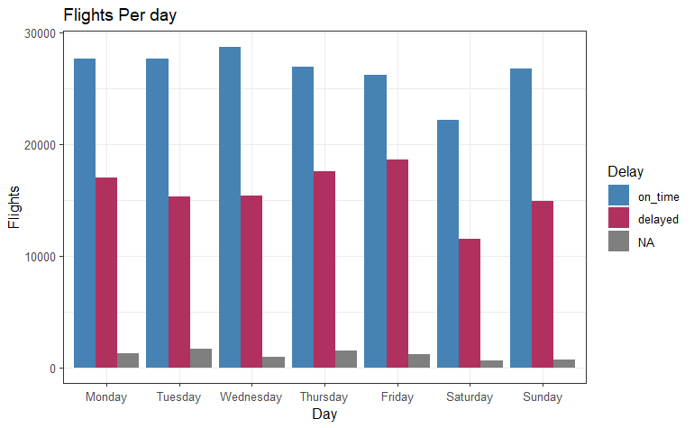

```r
clean_data %>%
    group_by(day = weekdays(POSIXct_local_time), delays =dep_delay_bool) %>%
    summarize(count = n()) %>%
    mutate(days = factor(day, levels = c("Monday", "Tuesday", "Wednesday", "Thursday", "Friday", "Saturday", "Sunday"))) %>%

ggplot(aes(x = days, y = count, fill = delays)) + geom_bar(stat='identity', position = "dodge") +
  labs(x = "Day",
y = "Flights",
title = "Flights Per day",
fill = "Delay") +
  scale_fill_manual(labels = c("on_time", "delayed"), values = c("steelblue", "maroon")) +
  theme_bw()
```

no obvious increase in delays by day but a reduced overall volume on saterday. saterday also seems to have a reduced percentage of delays. reduced volume of flights could allow the airport to more easily manage delays.

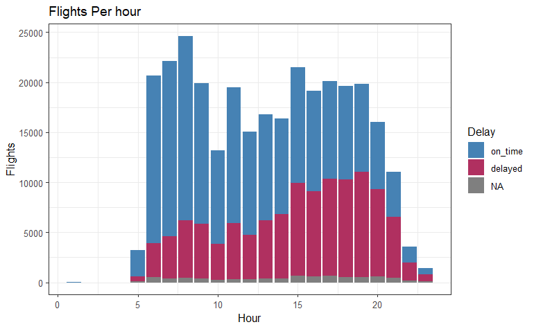

```r
clean_data %>%
    group_by(hour = hour(POSIXct_local_time), delays =dep_delay_bool) %>%
    summarize(count = n()) -> by_day
by_day%>%
ggplot(aes(x = hour, y = count, fill = delays)) + geom_bar(stat='identity') +
  labs(x = "Hour",
y = "Flights",
title = "Flights Per hour",
fill = "Delay") +
  scale_fill_manual(labels = c("on_time", "delayed"), values = c("steelblue", "maroon")) +
  theme_bw()
```

flights have a higher cancellation rate after midday and delays became more frequent after 3pm.

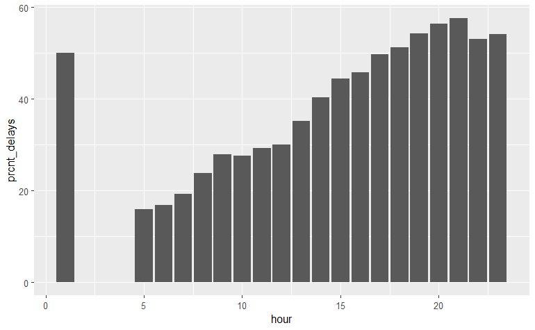

```r
clean_data %>%
    select(dep_delay_bool, POSIXct_local_time) %>%
    na.omit() %>%
    group_by(hour = hour(POSIXct_local_time)) %>%
    summarize(prcnt_delays = sum(dep_delay_bool)/n()*100) -> by_day_line

by_day_line%>%
ggplot(aes(x = hour, y = prcnt_delays)) + geom_bar(stat='identity')
```

an overall trend upward of delays by hour, this could indicate that the airport at 5AM has been reset overnight. as delays happen through the day the indirect effect of one could be the precursor to another.

```r
sapply(names(clean_data), function(x){mean(is.na(clean_data[[x]]))})
```

```
              flight              tailnum         airline_name   POSIXct_local_time         manufacturer     manufacture_year                model
         0.000000000          0.003262573          0.000000000          0.000000000          0.126308651          0.151849560          0.126308651
                type                seats               engine              engines                speed  origin_airport_name   origin_airport_alt
         0.126308651          0.128386031          0.126308651          0.126308651          0.985461633          0.000000000          0.000000000
origin_airport_tzone                 temp                 dewp             dew_bool                humid               precip             wind_dir
         0.000000000          0.977431950          0.977431950          0.977431950          0.977431950          0.947861385          0.081146213
          wind_speed            wind_gust             pressure                visib       sched_dep_time             dep_time            dep_delay
         0.080810409          0.080810409          0.981701937          0.002804957          0.000000000          0.025712103          0.025712103
    dep_delay_binary       dep_delay_bool            cancelled             air_time             distance
         0.025712103          0.025712103          0.000000000          0.029142579          0.000000000
```

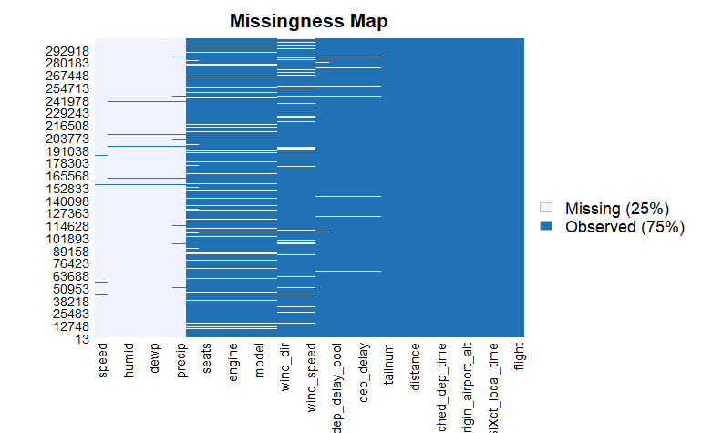

```r
missmap(clean_data,  rank.order = TRUE)
```

most weather data missing, wind and visibility still viable

```r
clean_data_f = clean_data %>%
  select("flight",
       "tailnum",
       "airline_name",
       "POSIXct_local_time",

       "manufacturer",
       "manufacture_year",
       "model",
       "type",
       "seats",
       "engine",
       "engines",
       "origin_airport_name",
       "origin_airport_alt",
       "origin_airport_tzone",
       "wind_dir",
       "wind_speed",
       "wind_gust",
       "visib",

       "sched_dep_time",
       "dep_time",
       "dep_delay",
       "dep_delay_binary",
       "dep_delay_bool",
       "cancelled",

       "air_time",
       "distance"
       )
```

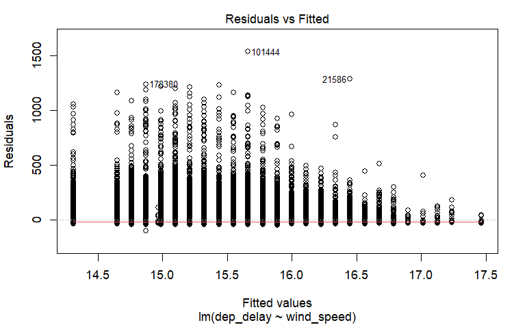

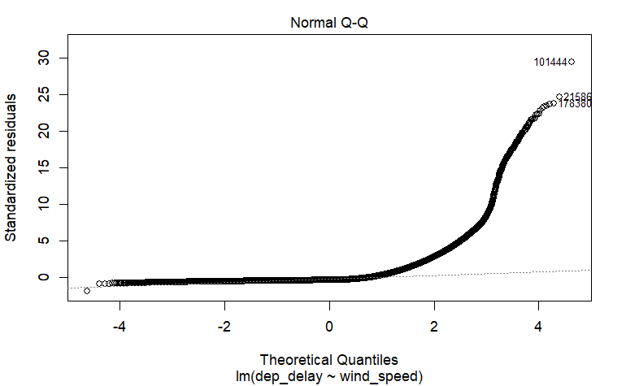

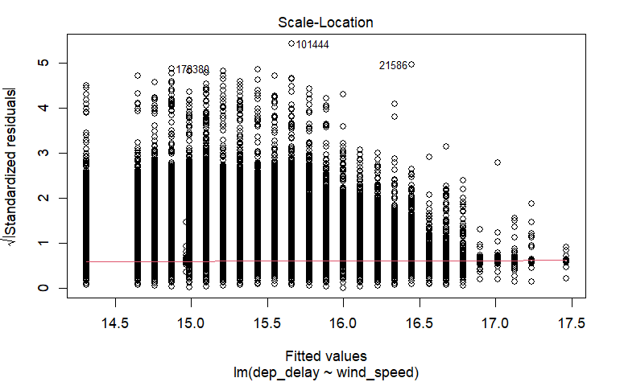

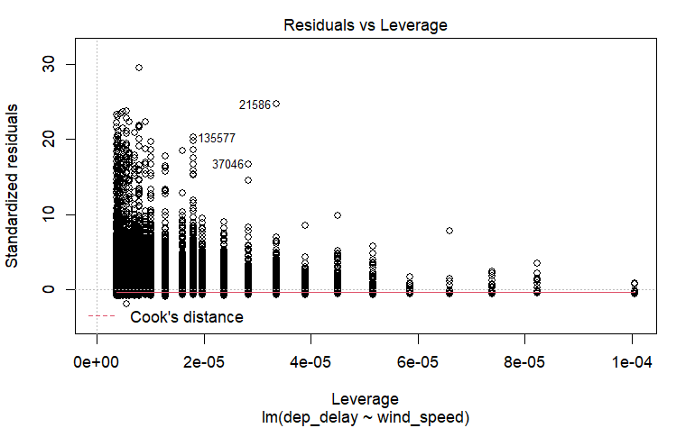

```r
lm1 <- lm(dep_delay~wind_speed, clean_data_f)

plot(lm1)
```

```r
summary(lm1)
```

```
Call:
lm(formula = dep_delay ~ wind_speed, data = clean_data_f)

Residuals:
    Min      1Q  Median      3Q     Max
 -98.87  -20.87  -17.22   -3.55 1532.34

Coefficients:
            Estimate Std. Error t value Pr(>|t|)
(Intercept) 14.31008    0.22085  64.794  < 2e-16 ***
wind_speed   0.09784    0.02201   4.444 8.81e-06 ***
---
Signif. codes:  0 ‘***’ 0.001 ‘**’ 0.01 ‘*’ 0.05 ‘.’ 0.1 ‘ ’ 1

Residual standard error: 52.06 on 272213 degrees of freedom
  (31533 observations deleted due to missingness)
Multiple R-squared:  7.256e-05, Adjusted R-squared:  6.889e-05
F-statistic: 19.75 on 1 and 272213 DF,  p-value: 8.815e-06
```

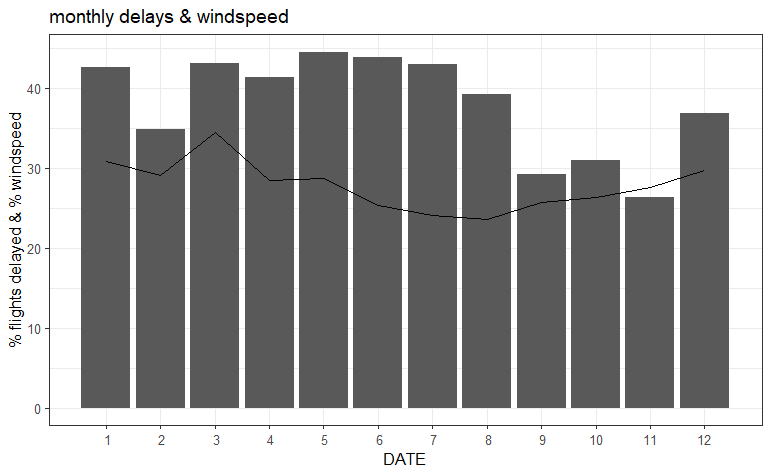

```r
wind_clean_data <- clean_data_f%>%
  select(dep_delay_binary, wind_speed, visib, seats, engines, POSIXct_local_time) %>% na.omit() %>%
  mutate(month = month(POSIXct_local_time))

wind_clean_data %>%

  group_by(month) %>%
  summarise(wind_speed = mean(wind_speed)/max(wind_clean_data$wind_speed)*100, prcnt_flights_delayed = sum(dep_delay_binary)/length(dep_delay_binary)*100) %>%


  ggplot(aes( x = month)) +
  geom_bar(aes(x = month, y = prcnt_flights_delayed), stat = "identity") +
  geom_line(aes(x = month, y = wind_speed), stat = "identity") +
  scale_x_discrete(limits = 1:12) +
  labs(x = "DATE",
y = "% flights delayed & % windspeed",
title = "monthly delays & windspeed",
fill = "Delay") +
  scale_fill_manual(labels = c("on_time", "delayed"), values = c("steelblue", "maroon")) +
  theme_bw()
```

bars = delays line = wind speed

possible correlation with wind speed, but not obvious enough to confirm, requires further research on more data. not accounting for human countermeasures already in place to reduce predicted delays due to predicted windspeed.

```r
wind_clean_data <- clean_data_f%>%
  select(dep_delay_binary, wind_speed, visib, seats, engines, POSIXct_local_time) %>% na.omit() %>%
  mutate(month = month(POSIXct_local_time))

index = sort(sample(nrow(wind_clean_data), nrow(wind_clean_data)*0.8))

train<-wind_clean_data[index,]
nrow(train)
```

```
[1] 190715
```

```r
test<-wind_clean_data[-index,]
nrow(test)
```

```
[1] 47679
```

```r
liniar_model <- glm(dep_delay_binary ~ wind_speed + visib + seats + engines, family = binomial(link = "logit"), data = train)


summary(liniar_model)
```

```
Call:
glm(formula = dep_delay_binary ~ wind_speed + visib + seats +
    engines, family = binomial(link = "logit"), data = train)

Deviance Residuals:
    Min       1Q   Median       3Q      Max
-1.3567  -0.9644  -0.9493   1.4018   1.4924

Coefficients:
              Estimate Std. Error z value Pr(>|z|)
(Intercept)  7.783e-02  5.356e-02   1.453 0.146163
wind_speed   3.463e-03  1.045e-03   3.316 0.000914 ***
visib       -8.928e-02  2.477e-03 -36.047  < 2e-16 ***
seats        3.341e-04  5.686e-05   5.875 4.23e-09 ***
engines      9.905e-02  2.513e-02   3.942 8.07e-05 ***
---
Signif. codes:  0 ‘***’ 0.001 ‘**’ 0.01 ‘*’ 0.05 ‘.’ 0.1 ‘ ’ 1

(Dispersion parameter for binomial family taken to be 1)

    Null deviance: 253681  on 190714  degrees of freedom
Residual deviance: 252311  on 190710  degrees of freedom
AIC: 252321

Number of Fisher Scoring iterations: 4
```

```r
prediction <- predict(liniar_model, newdata = test, type = "response")
head(prediction)
```

```
        1         2         3         4         5         6
0.3763122 0.3781062 0.3684940 0.3657774 0.3779601 0.3701388
```

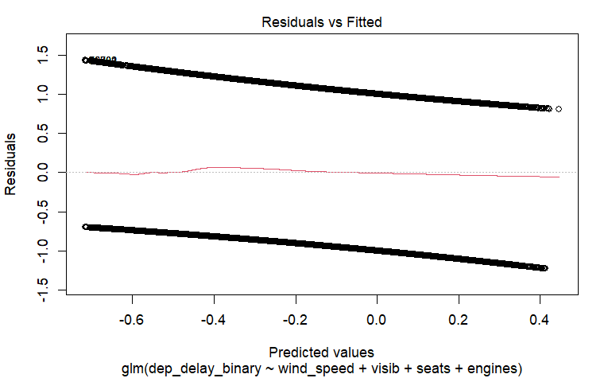

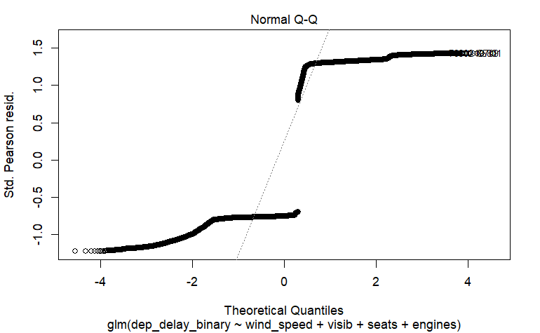

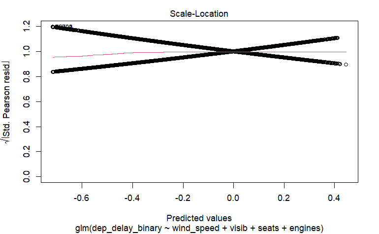

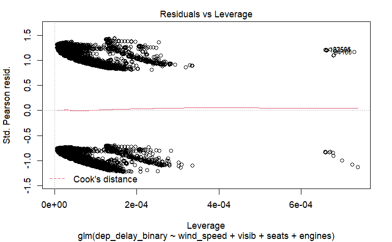

```r
prediction_binary <- factor(ifelse(prediction > 0.5, 1, 0))
plot(liniar_model)
```

```r
confusionMatrix(prediction_binary, factor(test$dep_delay_binary))
```

```
Confusion Matrix and Statistics

          Reference
Prediction     0     1
         0 28556 16904
         1  1050  1169

               Accuracy : 0.6234
                 95% CI : (0.6191, 0.6278)
    No Information Rate : 0.6209
    P-Value [Acc > NIR] : 0.1316

                  Kappa : 0.0352

 Mcnemar's Test P-Value : <2e-16

            Sensitivity : 0.96453
            Specificity : 0.06468
         Pos Pred Value : 0.62816
         Neg Pred Value : 0.52681
             Prevalence : 0.62094
         Detection Rate : 0.59892
   Detection Prevalence : 0.95346
      Balanced Accuracy : 0.51461

       'Positive' Class : 0
```

```r
with(summary(liniar_model), 1 - deviance/null.deviance)
```

```
[1] 0.005402069
```

[output not shown]

```r
index = sort(sample(nrow(wind_clean_data), nrow(wind_clean_data)*0.8))

train<-wind_clean_data[index,]
nrow(train)
```

```
[1] 190715
```

```r
test<-wind_clean_data[-index,]
nrow(test)
```

```
[1] 47679
```

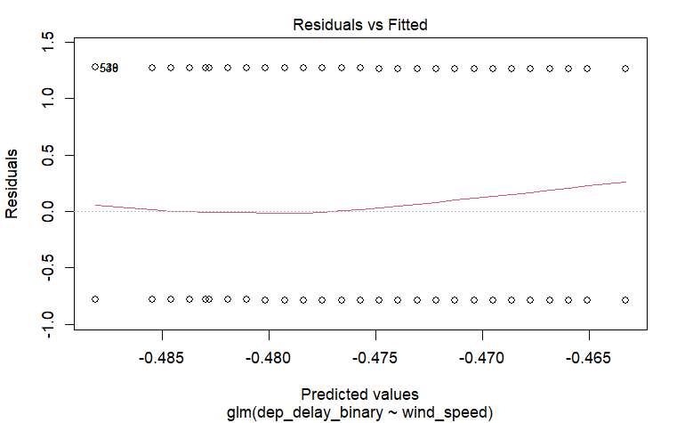

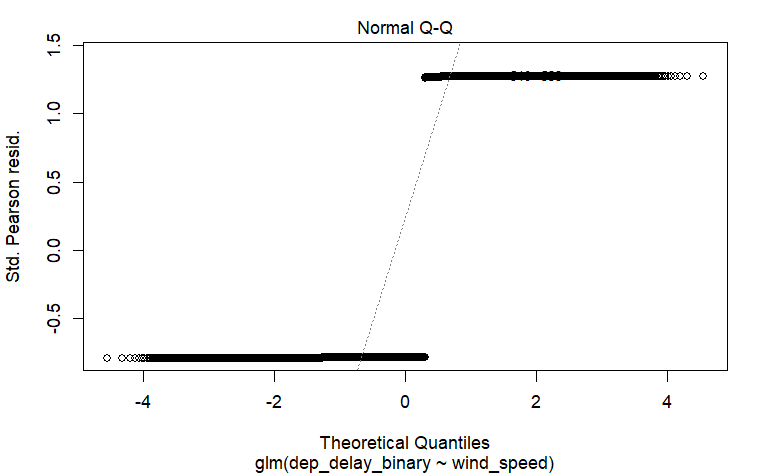

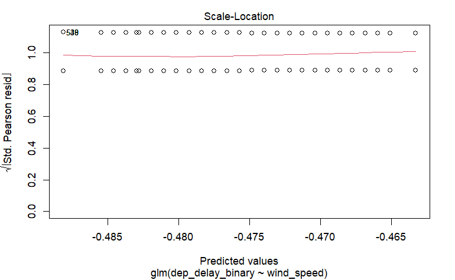

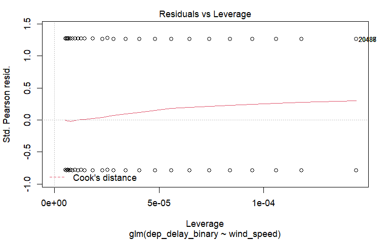

```r
fit <- glm(dep_delay_binary ~ wind_speed, family = binomial(link = "logit"), data = train)

result <- predict(fit, newdata=test, type="response")

plot(fit)
```

```r
summary(fit)
```

```
Call:
glm(formula = dep_delay_binary ~ wind_speed, family = binomial(link = "logit"),
    data = train)

Deviance Residuals:
    Min       1Q   Median       3Q      Max
-0.9880  -0.9811  -0.9797   1.3869   1.3905

Coefficients:
              Estimate Std. Error z value Pr(>|z|)
(Intercept) -0.4881479  0.0103988 -46.943   <2e-16 ***
wind_speed   0.0007709  0.0010389   0.742    0.458
---
Signif. codes:  0 ‘***’ 0.001 ‘**’ 0.01 ‘*’ 0.05 ‘.’ 0.1 ‘ ’ 1

(Dispersion parameter for binomial family taken to be 1)

    Null deviance: 253655  on 190714  degrees of freedom
Residual deviance: 253655  on 190713  degrees of freedom
AIC: 253659

Number of Fisher Scoring iterations: 4
```

```r
clean_data_f %>%
  filter(dep_delay_binary = TRUE) %>%
  select(dep_delay, visib) %>%
  na.omit() %>%
  group_by(visib) %>%
  #summarise(avg_delay_count = mean(dep_delay)) -> vis_data

  summarise(avg_delay_count = dep_delay) -> vis_data
vis_data
```

| visib | avg_delay_count |
| --- | --- |
| 0.12 | 10 |
| 0.12 | -2 |
| 0.12 | 24 |
| 0.12 | -1 |
| 0.12 | -1 |
| 0.12 | 21 |
| 0.12 | 36 |
| 0.12 | -1 |
| 0.12 | -7 |
| 0.12 | 0 |

[output cut: 990 more lines]

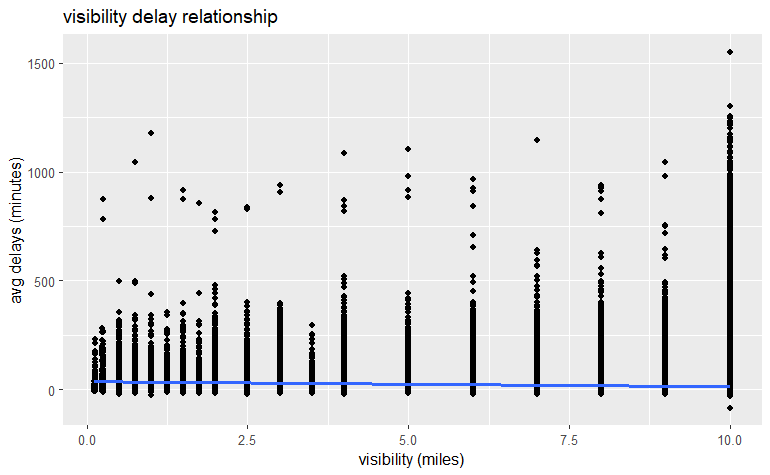

```r
vis_data %>%

ggplot(aes(x = visib, y = avg_delay_count)) +
geom_point() +
geom_smooth(method = "lm") +
labs(x = "visibility (miles)",
y = "avg delays (minutes)",
title = "visibility delay relationship")
```

long visibility seems to be a predictor for reduced delay magnitude. more apparent when plotted as an avarage of avarages however this may be misleading. while the data points seem to show a delay increase with longer visibility, the general trend of this distribution is slightly downward.

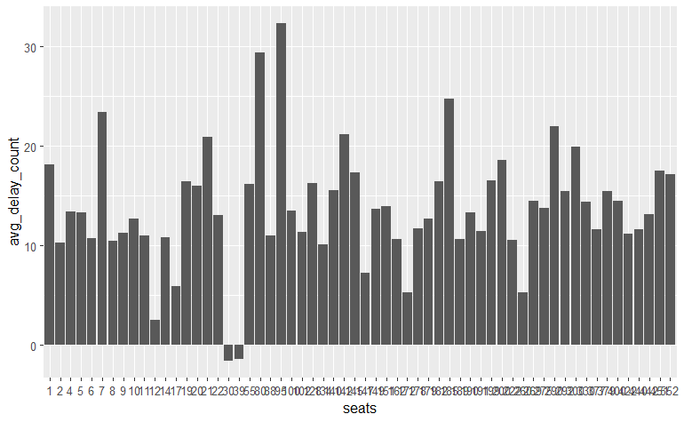

```r
clean_data_f %>%
  filter(dep_delay_bool = TRUE) %>%
  select(dep_delay, seats) %>%
  mutate(seats = factor(seats)) %>%
  na.omit() %>%
  group_by(seats) %>%
  summarise(avg_delay_count = mean(dep_delay)) %>%
  ggplot() +
    geom_bar(aes(x = seats, y = avg_delay_count), stat = "identity")
```

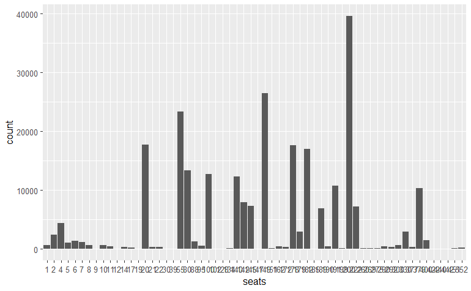

```r
clean_data_f %>%
    filter(dep_delay_bool = TRUE) %>%
  select(dep_delay, seats) %>%
  mutate(seats = factor(seats)) %>%
  na.omit() %>%
  group_by(seats) %>%
  summarise(count = n()) %>%
  ggplot() +
    geom_bar(aes(x = seats, y = count), stat = "identity")
```

certain seat number planes appear much more common indicating a set of plane sizes used for regular civilian transport.